# Complete3

Import necessary libraries:

Pandas - Data Manipulation & Analysis

Sklearn - Machine Learning

Seaborn - Data Visualization

Matplotlib - Data Visualization

```python
import pandas as pd
from sklearn.model_selection import train_test_split
from sklearn.ensemble import RandomForestClassifier
import seaborn as sns
import matplotlib.pyplot as plt
from sklearn.metrics import confusion_matrix, accuracy_score, precision_score, recall_score, f1_score
```

Read data set into dataframe labeled "medicalData"

```python
medicalData = pd.read_csv('/Users/oscarescobar/Desktop/breast-cancer.csv')
```

How does our data look?

```python
print(medicalData.info())
```

```
<class 'pandas.core.frame.DataFrame'>
RangeIndex: 569 entries, 0 to 568
Data columns (total 32 columns):
 #   Column                   Non-Null Count  Dtype
---  ------                   --------------  -----
 0   id                       569 non-null    int64
 1   diagnosis                569 non-null    object
 2   radius_mean              569 non-null    float64
 3   texture_mean             569 non-null    float64
 4   perimeter_mean           569 non-null    float64
 5   area_mean                569 non-null    float64
 6   smoothness_mean          569 non-null    float64
 7   compactness_mean         569 non-null    float64
 8   concavity_mean           569 non-null    float64
 9   concave points_mean      569 non-null    float64
```

[output cut: 25 more lines]

Lets drop any duplicates in the dataset

```python
medicalData = medicalData.drop_duplicates()
```

```python
print(medicalData.head())
```

```
         id diagnosis  radius_mean  texture_mean  perimeter_mean  area_mean  \
0    842302         M        17.99         10.38          122.80     1001.0
1    842517         M        20.57         17.77          132.90     1326.0
2  84300903         M        19.69         21.25          130.00     1203.0
3  84348301         M        11.42         20.38           77.58      386.1
4  84358402         M        20.29         14.34          135.10     1297.0

   smoothness_mean  compactness_mean  concavity_mean  concave points_mean  \
0          0.11840           0.27760          0.3001              0.14710
1          0.08474           0.07864          0.0869              0.07017
2          0.10960           0.15990          0.1974              0.12790
3          0.14250           0.28390          0.2414              0.10520
4          0.10030           0.13280          0.1980              0.10430

   ...  radius_worst  texture_worst  perimeter_worst  area_worst  \
```

[output cut: 21 more lines]

Drop ID for proper analysis and model building

```python
medicalData = medicalData.drop(columns = ['id'])
```

```python
print(medicalData.head())
```

```
  diagnosis  radius_mean  texture_mean  perimeter_mean  area_mean  \
0         M        17.99         10.38          122.80     1001.0
1         M        20.57         17.77          132.90     1326.0
2         M        19.69         21.25          130.00     1203.0
3         M        11.42         20.38           77.58      386.1
4         M        20.29         14.34          135.10     1297.0

   smoothness_mean  compactness_mean  concavity_mean  concave points_mean  \
0          0.11840           0.27760          0.3001              0.14710
1          0.08474           0.07864          0.0869              0.07017
2          0.10960           0.15990          0.1974              0.12790
3          0.14250           0.28390          0.2414              0.10520
4          0.10030           0.13280          0.1980              0.10430

   symmetry_mean  ...  radius_worst  texture_worst  perimeter_worst  \
```

[output cut: 21 more lines]

Lets fix the diagnosis column from M (malignant) to 1 and B (benign) to 0

```python
medicalData['diagnosis'] = medicalData['diagnosis'].map({'M': 1, 'B': 0})
```

```python
print(medicalData.head())
```

```
  diagnosis  radius_mean  texture_mean  perimeter_mean  area_mean  \
0         1        17.99         10.38          122.80     1001.0
1         1        20.57         17.77          132.90     1326.0
2         1        19.69         21.25          130.00     1203.0
3         1        11.42         20.38           77.58      386.1
4         1        20.29         14.34          135.10     1297.0

   smoothness_mean  compactness_mean  concavity_mean  concave points_mean  \
0          0.11840           0.27760          0.3001              0.14710
1          0.08474           0.07864          0.0869              0.07017
2          0.10960           0.15990          0.1974              0.12790
3          0.14250           0.28390          0.2414              0.10520
4          0.10030           0.13280          0.1980              0.10430

   symmetry_mean  ...  radius_worst  texture_worst  perimeter_worst  \
```

[output cut: 21 more lines]

```python
print(medicalData['diagnosis'].unique())
print(medicalData['diagnosis'].dtype)
```

[output not shown]

```python
print(medicalData.info())
```

[output not shown]

[output cut: 24 more lines]

Now, lets do some Explorative Data Analysis on the dataset

Manually counting the proportion of target cases in the whole data set

```python
count=[]
for i in range(len(medicalData)):
    if medicalData['diagnosis'][i] == 1:
        count.append(1)
    else:
        count.append(0)

print(sum(count)/len(count))
```

```
0.37258347978910367
```

Plotting distributions

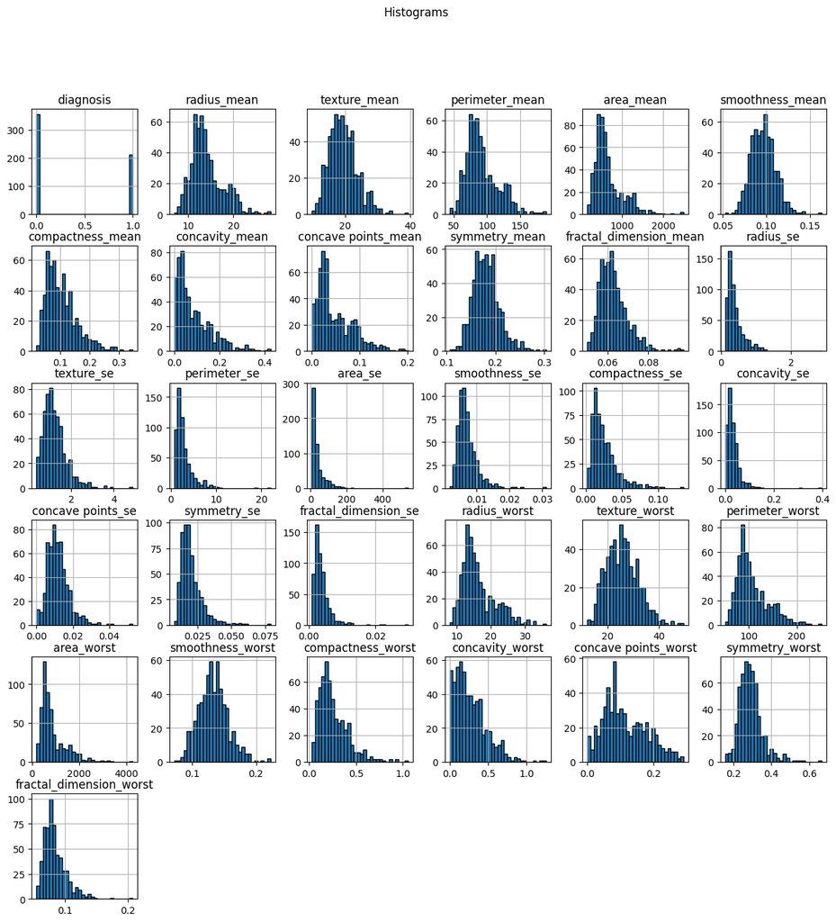

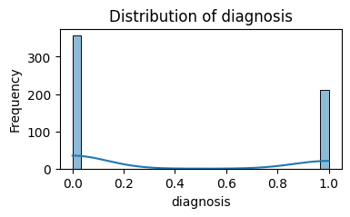

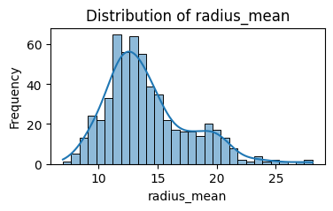

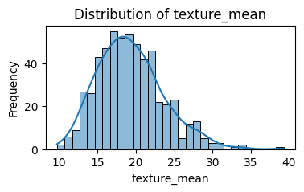

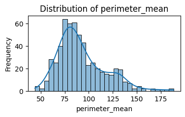

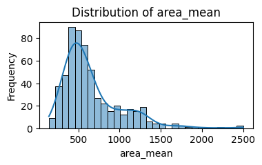

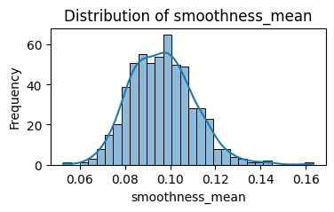

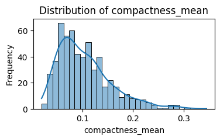

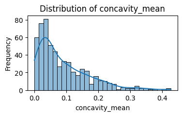

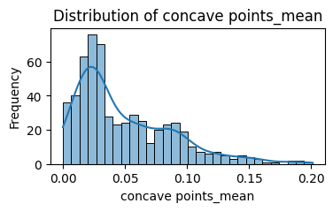

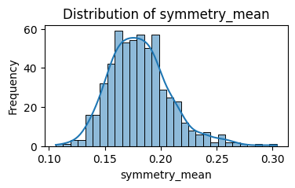

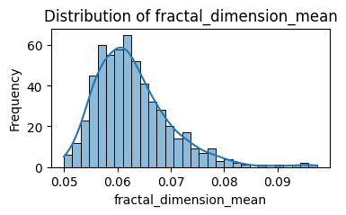

[20 more figures not shown]

```python
medicalData.hist(figsize=(15, 15), bins=30, edgecolor='black')
plt.suptitle("Histograms")
plt.show()
num_cols = medicalData.select_dtypes(include=['number']).columns

for col in num_cols:
    plt.figure(figsize=(4, 2))
    sns.histplot(medicalData[col], kde=True, bins=30)
    plt.title(f'Distribution of {col}')
    plt.xlabel(col)
    plt.ylabel('Frequency')
    plt.show()
```

Now lets prepare our data for training and testing

```python
print(medicalData.columns)
```

```
Index(['diagnosis', 'radius_mean', 'texture_mean', 'perimeter_mean',
       'area_mean', 'smoothness_mean', 'compactness_mean', 'concavity_mean',
       'concave points_mean', 'symmetry_mean', 'fractal_dimension_mean',
       'radius_se', 'texture_se', 'perimeter_se', 'area_se', 'smoothness_se',
       'compactness_se', 'concavity_se', 'concave points_se', 'symmetry_se',
       'fractal_dimension_se', 'radius_worst', 'texture_worst',
       'perimeter_worst', 'area_worst', 'smoothness_worst',
       'compactness_worst', 'concavity_worst', 'concave points_worst',
       'symmetry_worst', 'fractal_dimension_worst'],
      dtype='object')
```

Lets create the X and Y sets

X is the rows and columns of the predictors

Y is the rows and column of the target

```python
X = medicalData.iloc[:,1:31].values
Y = medicalData.iloc[:,0].values
```

Use train_test_split() for model cross validation

```python
X_train, X_test, Y_train, Y_test = train_test_split(X, Y,test_size=0.2, stratify=Y, random_state=3141)
```

Fit the model using RandomForestClassifier() and the training set

```python
rf_class = RandomForestClassifier()
rf_class.fit(X_train, Y_train)
```

```
RandomForestClassifier()
```

Finding variable importance

```python
var_names = pandas.DataFrame(['radius_mean', 'texture_mean', 'perimeter_mean',
       'area_mean', 'smoothness_mean', 'compactness_mean', 'concavity_mean',
       'concave points_mean', 'symmetry_mean', 'fractal_dimension_mean',
       'radius_se', 'texture_se', 'perimeter_se', 'area_se', 'smoothness_se',
       'compactness_se', 'concavity_se', 'concave points_se', 'symmetry_se',
       'fractal_dimension_se', 'radius_worst', 'texture_worst',
       'perimeter_worst', 'area_worst', 'smoothness_worst',
       'compactness_worst', 'concavity_worst', 'concave points_worst',
       'symmetry_worst', 'fractal_dimension_worst'])
loss_reduction = pandas.DataFrame(rf_class.feature_importances_, columns = ['loss_reduction'])
var_importance = pandas.concat([var_names, loss_reduction], axis = 1)
var_importance = var_importance.sort_values('loss_reduction', axis = 0, ascending= False)
print(var_importance)
```

```
                          0  loss_reduction
27     concave points_worst        0.141722
22          perimeter_worst        0.130600
23               area_worst        0.106132
20             radius_worst        0.105453
0               radius_mean        0.072884
3                 area_mean        0.056955
7       concave points_mean        0.047261
6            concavity_mean        0.045754
13                  area_se        0.044653
2            perimeter_mean        0.036234
26          concavity_worst        0.034032
25        compactness_worst        0.023313
5          compactness_mean        0.019139
1              texture_mean        0.015489
```

[output cut: 16 more lines]

Now lets generate some metrics to check the performance of this basic model.

First we generate accuracy

```python
Y_pred = rf_class.predict(X_test)
Y_test = pandas.DataFrame(Y_test, columns = ['Cancer'])
Y_pred = pandas.DataFrame(Y_pred, columns = ['Prediction'])
df = pandas.concat([Y_test, Y_pred], axis = 1)
count = (df['Cancer'] == df['Prediction']).sum()
print(count/len(df))
```

```
0.956140350877193
```

Now lets produce a confusion matrix and visualize it using a heatmap

```python
from sklearn.metrics import confusion_matrix

cm = confusion_matrix(Y_test, Y_pred)
print(cm)
```

```
[[71  1]
 [ 4 38]]
```

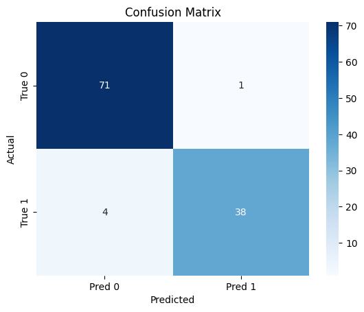

```python
sns.heatmap(cm, annot = True,
            fmt="d",
            cmap="Blues",
            xticklabels=['Pred 0', 'Pred 1'],
            yticklabels=['True 0', 'True 1'])
plt.xlabel("Predicted")
plt.ylabel("Actual")
plt.title("Confusion Matrix")
plt.show()
```

Lastly, lets generate the entire set of metrics that can be used to evaluate and compare different models

```python
tn, fp, fn, tp = confusion_matrix(Y_test, Y_pred).ravel()

sensitivity = tp / (tp + fn)
specificity = tn / (tn + fp)
precision = precision_score(Y_test, Y_pred)
recall = recall_score(Y_test, Y_pred)
f1 = f1_score(Y_test, Y_pred)
accuracy = accuracy_score(Y_test, Y_pred)

print(f"Accuracy: {accuracy:.4f}")
print(f"Sensitivity (Recall): {sensitivity:.4f}")
print(f"Specificity: {specificity:.4f}")
print(f"Precision: {precision:.4f}")
print(f"F1-score: {f1:.4f}")
```

```
Accuracy: 0.9561
Sensitivity (Recall): 0.9048
Specificity: 0.9861
Precision: 0.9744
F1-score: 0.9383
```